# Reproduceacble Research

## 4.Make a histogram of the total number of steps taken each day and Calculate and report the mean and median total number of steps taken per day. Do these values differ from the estimates from the first part of the assignment? What is the impact of imputing missing data on the estimates of the total daily number of steps?

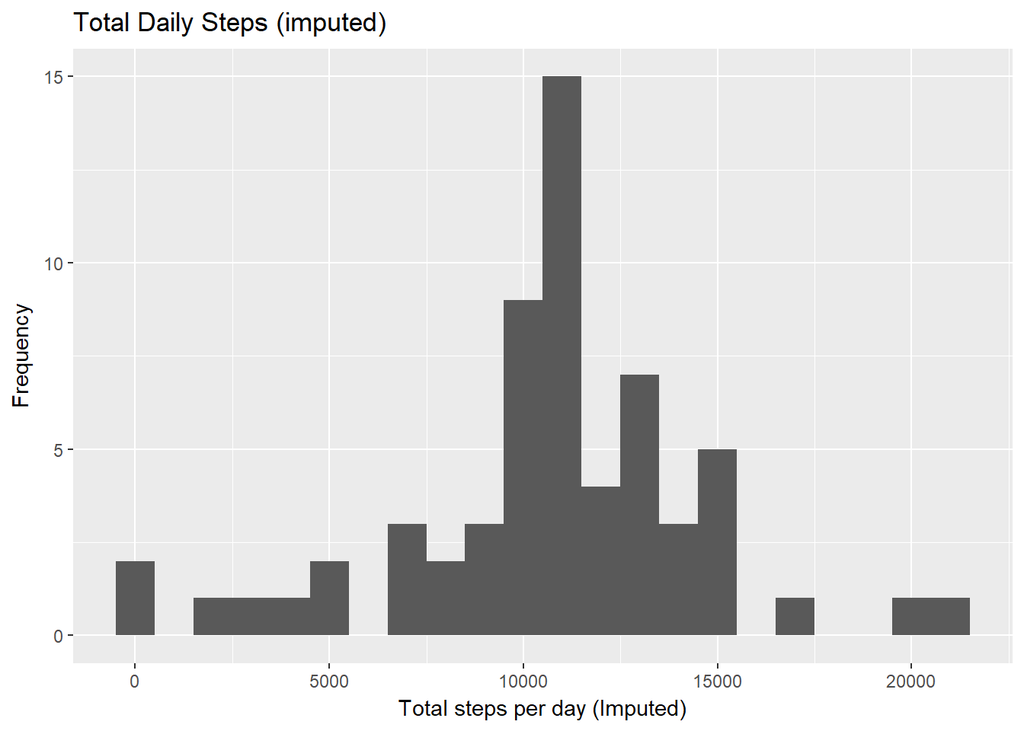

```r
hist <- ggplot(data = stepsByDayImputed,aes(x=steps))+geom_histogram(binwidth = 1000)+labs(title="Total Daily Steps (imputed)",x= "Total steps per day (Imputed)",y= "Frequency")
print(hist)
```

```r
mean(stepsByDayImputed$steps)
```

```
## [1] 10766.19
```

```r
median(stepsByDayImputed$steps)
```

```
## [1] 10766.19
```

## Are there differences in activity patterns between weekdays and weekends?

```r
activityDataImputed$weekday <- weekdays(as.Date(activityDataImputed$date))
activityDataImputed$weekend<- ifelse(activityDataImputed$weekday== "Saturday" | activityDataImputed$weekday== "Sunday" , "weekend", "weekday")
head(activityDataImputed)
```

```
##     steps       date interval weekday weekend
## 1 37.3826 2012-10-01        0  Monday weekday
## 2 37.3826 2012-10-01        5  Monday weekday
## 3 37.3826 2012-10-01       10  Monday weekday
## 4 37.3826 2012-10-01       15  Monday weekday
## 5 37.3826 2012-10-01       20  Monday weekday
## 6 37.3826 2012-10-01       25  Monday weekday
```

```r
meanData <- aggregate(activityDataImputed$steps,by=list(activityDataImputed$weekend,activityDataImputed$interval),mean)
head(meanData)
```

```
##   Group.1 Group.2        x
## 1 weekday       0 7.006569
## 2 weekend       0 4.672825
## 3 weekday       5 5.384347
## 4 weekend       5 4.672825
## 5 weekday      10 5.139902
## 6 weekend      10 4.672825
```

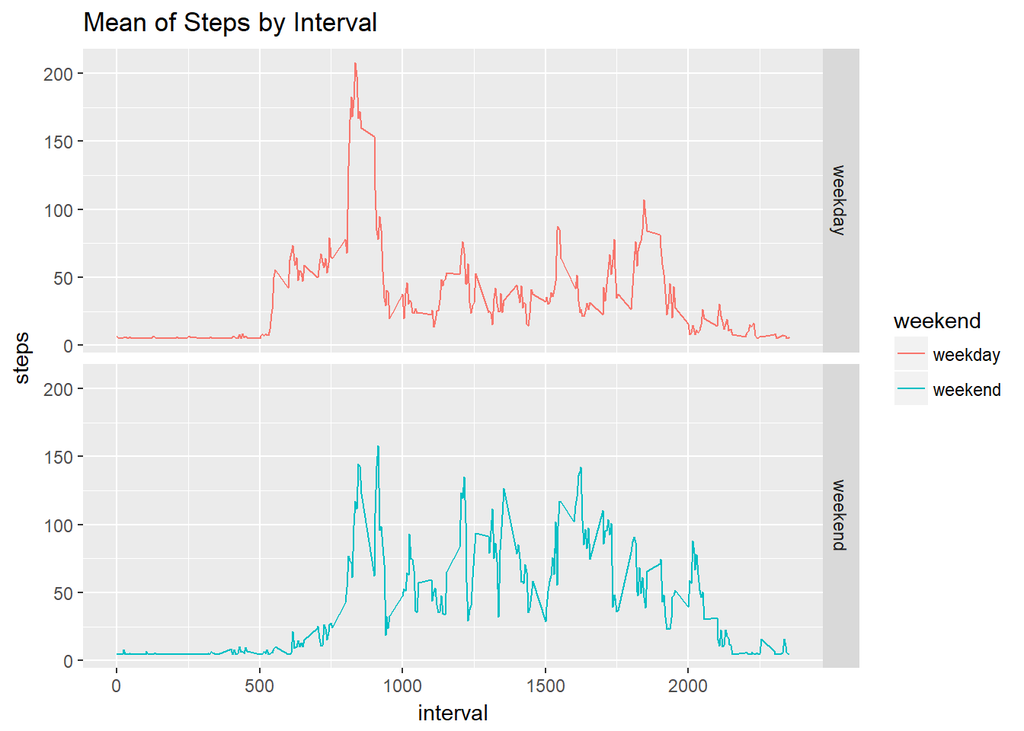

```r
names(meanData)[1]<- "weekend"
names(meanData)[2]<- "interval"
names(meanData)[3]<- "steps"
ggplot(data = meanData,aes(x=interval,y=steps,color=weekend))+geom_line()+facet_grid(weekend ~ .) + labs(title = "Mean of Steps by Interval", x = "interval", y = "steps")
```

There seems to be variation in the beginning of the day during weekdays, likely due to workplace activities. There seems to be an overall slightly larger incidence of steps during the weekends.